# State Coronavirus Data

Suppose that the full process is run to look at time from hospitalization to death:

```
##
## Will scale by: 0.04114457
```

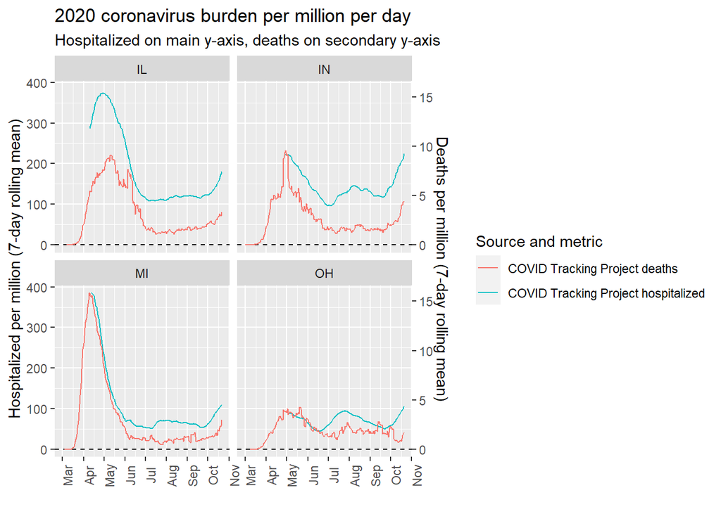

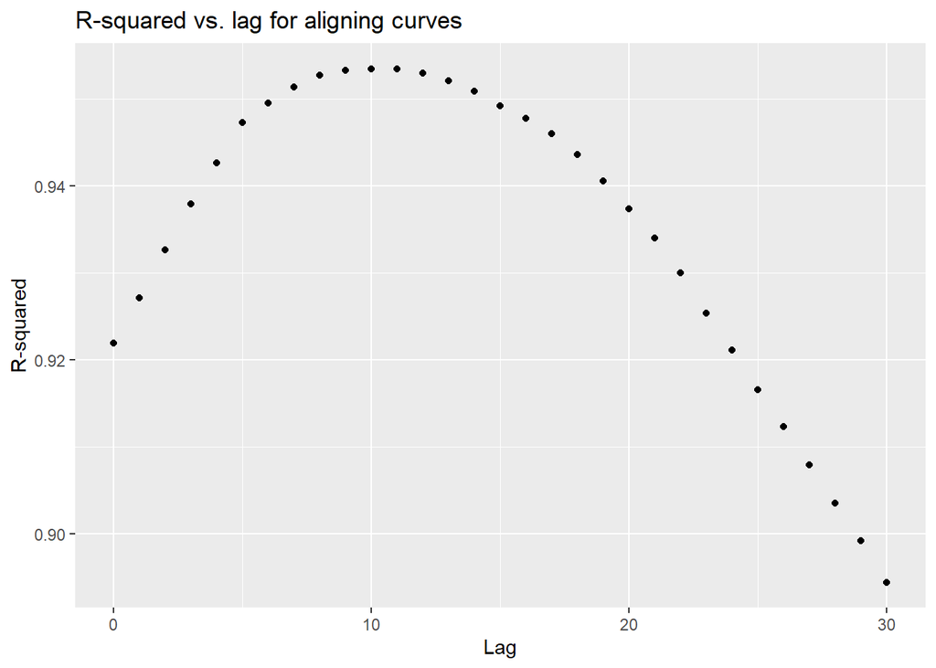

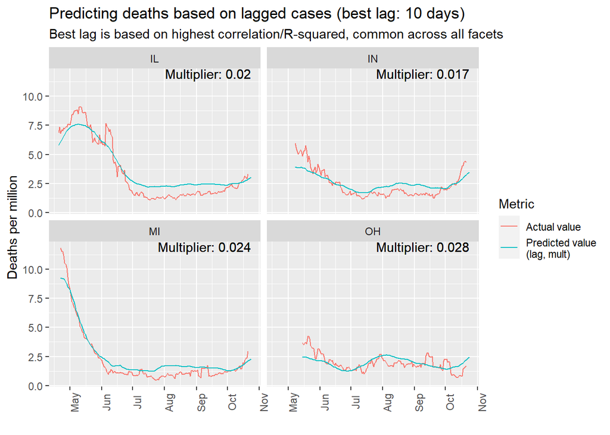

```r
# Example for midwestern states
mwHospDeathList <- createAndAlignCurves(stateData,
                                        yVal="vpm7",
                                        namesPlot=c("CTP_hosp"),
                                        namesSec=c("CTP_deaths"),
                                        keyStates=c("OH", "MI", "IN", "IL"),
                                        plotTitle="2020 coronavirus burden per million per day",
                                        plotSub="Hospitalized on main y-axis, deaths on secondary y-axis",
                                        primYLab="Hospitalized per million (7-day rolling mean)",
                                        secYLab="Deaths per million (7-day rolling mean)",
                                        facetFixed=TRUE,
                                        popData=usafPrepped$usafDemo,
                                        printPlot=TRUE,
                                        lagValueMetric="vpm7",
                                        lagDepName="CTP_deaths",
                                        lagsTry=0:30
                                        )
```

```r
# Deaths vs. cases in midwestern states
mwHospOut <- assessStateCFR(mwHospDeathList,
                        keyStates=c("OH", "MI", "IL", "IN"),
                        depVar="CTP_deaths",
                        indepVar="CTP_hosp",
                        depTitleName="deaths",
                        indepTitleName="hospitalized",
                        lagEarlyValue=NULL,
                        lagLateValue=NULL
                        )
```

```
## # A tibble: 4 x 3
##   state earlyLag lateLag
##   <chr>    <int>   <int>
## 1 MI           3       0
## 2 IN           5       3
## 3 OH           7      30
## 4 IL           9       7
```

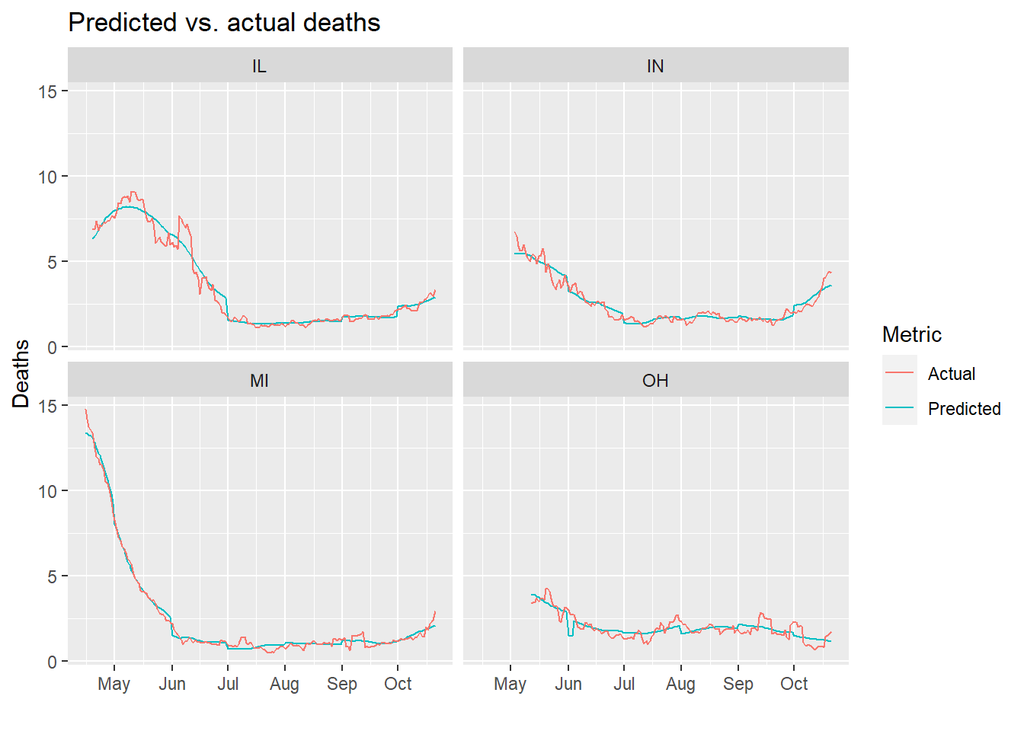

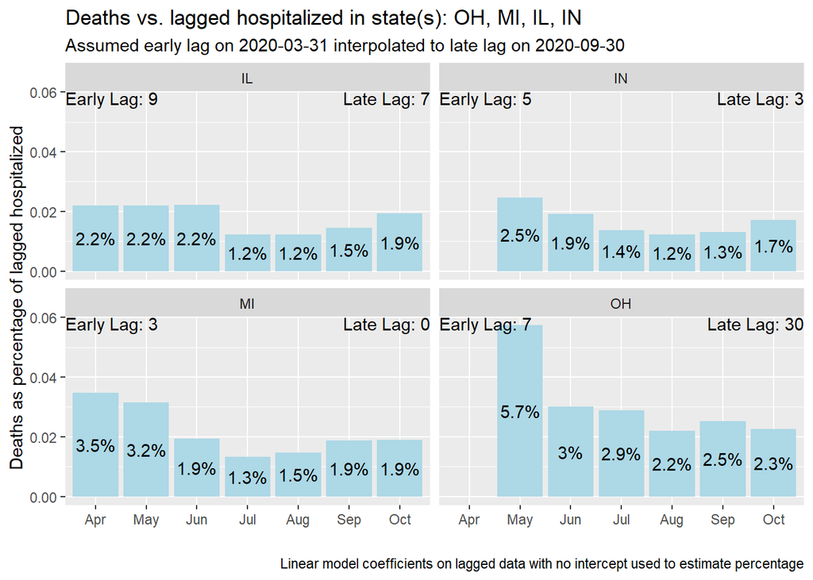

Total number in the hospital (note that this is not new hospitalizations) appears to be a fairly strong predictor of coronavirus deaths in the next week or so.

Suppose that a goal is to look at correlations between two metrics using 1) different lags, and 2) different windows of time. Suppose that there are two vectors of equal length, perfectly correlated on a lagged basis:

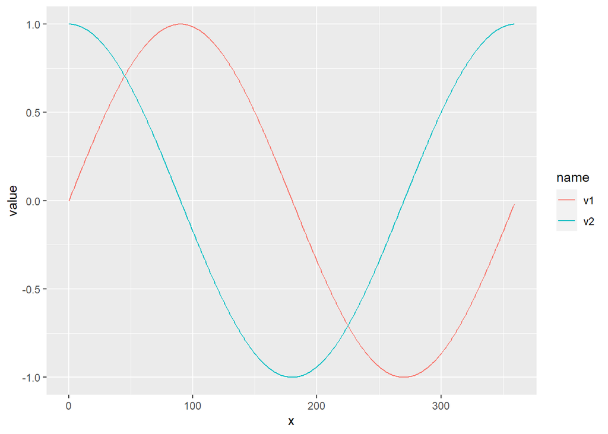

```r
v1 <- sin((0:359) * pi / 180)
v2 <- cos((0:359) * pi / 180)
tibble::tibble(x=0:359, v1=v1, v2=v2) %>%
    pivot_longer(-x) %>%
    ggplot(aes(x=x, y=value)) +
    geom_line(aes(group=name, color=name))
```

Correlations can be explored on various lags of the data:

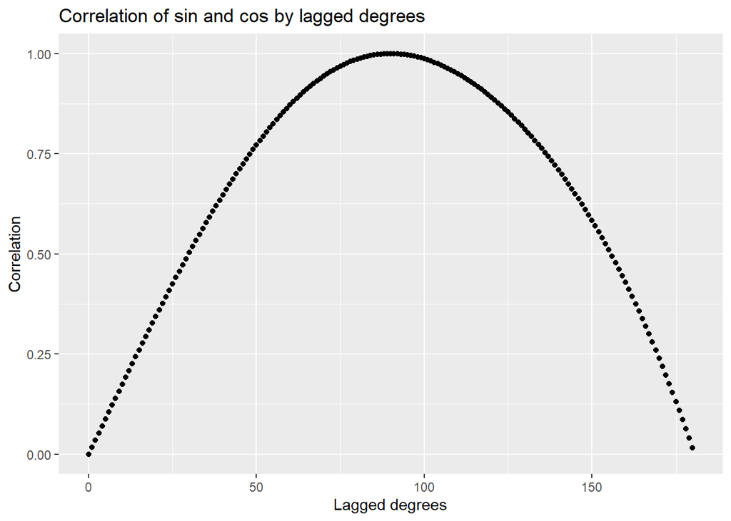

```r
tibble::tibble(lags=0:180) %>%
    mutate(p=sapply(lags, FUN=function(x) cor(v1, lag(v2, x), use="complete.obs"))) %>%
    ggplot(aes(x=lags, y=p)) +
    geom_point() +
    labs(x="Lagged degrees", y="Correlation", title="Correlation of sin and cos by lagged degrees")
```

As expected, the curves are perfectly correlated with a 90-degree lag. Suppose another goal is to find the best lag (lag producing the highest correlation) based on only a “window” of the data. Essentially, for each lag, run a subset of [start:(start+window-1)] for the relevant vectors. A function is written:

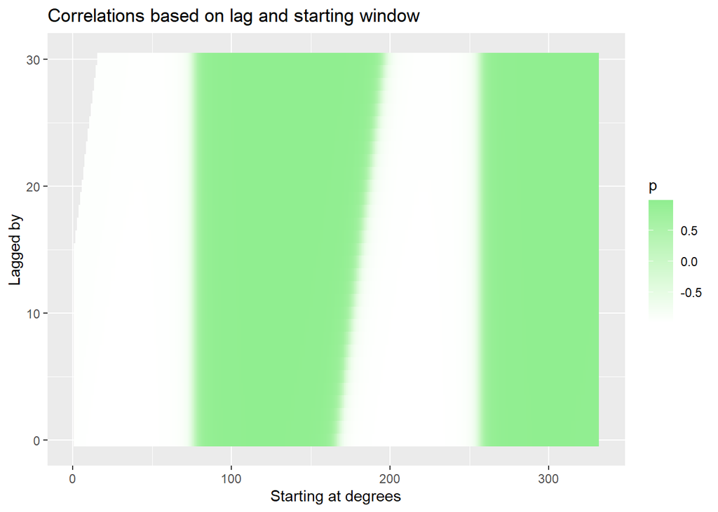

```r
lagVectorWindows <- function(v1,
                             v2,
                             lagsTry=0:30,
                             windowSize=30,
                             minNoNA=ceiling(windowSize/2),
                             updateStatus=FALSE
                             ) {

    # FUNCTION ARGUMENTS:
    # v1: the first vector, which will be used 'as is'
    # v2: the second vector, which will be lagged by various values for lagsTry
    # lagsTry: the values for lag that will be used in cor(v1, lag(v2, lag))
    # windowSize: the size of the window to use in taking snippets of v1 and lagged v2
    # minNoNA: minimum number of non-NA lagged values needed to calculate a correlation
    # updateStates: whether to print which window is being worked on

    # Find the list of all possible window start points
    windowStarts <- 1:(length(v1)-windowSize+1)

    # Helper function to create a frame of correlations
    helperCorr <- function(s) {

        # Create the end point for the vector
        e <- s + windowSize - 1

        # Announce the start
        if (updateStatus) cat("\nProcessing window starting at:", s)

        # Create the correlations tibble for all values of lag, and return
        tibble::tibble(startWindow=s, endWindow=e, lags=lagsTry) %>%
            mutate(na1=sum(is.na(v1[s:e])),
                   na2=sapply(lags, FUN=function(x) sum(is.na(lag(v2, x)[s:e]))),
                   p=sapply(lags,
                            FUN=function(x) {
                                ifelse(sum(!is.na(lag(v2, x)[s:e])) < minNoNA,
                                       NA,
                                       cor(v1[s:e], lag(v2, x)[s:e], use="complete.obs")
                                       )
                                }
                            )
                   )
    }

    # Bind the correlations frames and return
    map_dfr(windowStarts, .f=helperCorr)

}

tmpDB <- lagVectorWindows(v1=v1, v2=v2)

tmpDB %>%
    filter(!is.na(p)) %>%
    ggplot(aes(x=startWindow, y=lags)) +
    geom_tile(aes(fill=p)) +
    scale_fill_continuous(low="white", high="lightgreen") +
    labs(x="Starting at degrees", y="Lagged by", title="Correlations based on lag and starting window")
```

The correlations are (essentially) 1 when the curves are both going up/down at the same time, and are (essentially) -1 when one curve rises at the same time that the other curve falls. This is driven by 30 degrees being a much too small window. Suppose instead that windows of 90 degrees are applied:

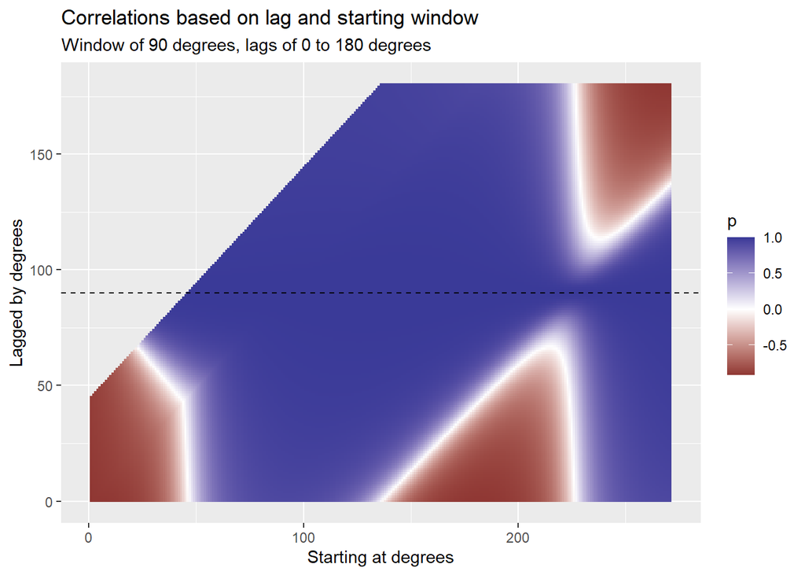

```r
tmpDB <- lagVectorWindows(v1=v1, v2=v2, windowSize=90, lagsTry=0:180)

tmpDB %>%
    filter(!is.na(p)) %>%
    ggplot(aes(x=startWindow, y=lags)) +
    geom_tile(aes(fill=p)) +
    scale_fill_gradient2(midpoint=0) +
    labs(x="Starting at degrees",
         y="Lagged by degrees",
         title="Correlations based on lag and starting window",
         subtitle="Window of 90 degrees, lags of 0 to 180 degrees"
         ) +
    geom_hline(yintercept=90, lty=2)
```

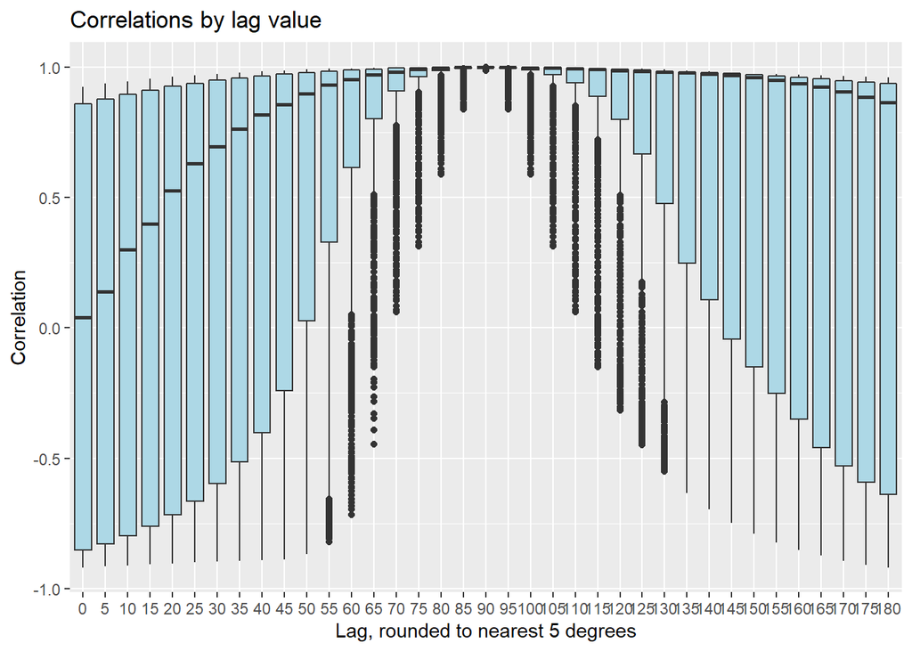

```r
tmpDB %>%
    filter(!is.na(p)) %>%
    mutate(lags=round(lags/5, 0)*5) %>%
    ggplot(aes(x=factor(lags), y=p)) +
    geom_boxplot(fill="lightblue") +
    labs(x="Lag, rounded to nearest 5 degrees", y="Correlation", title="Correlations by lag value")
```

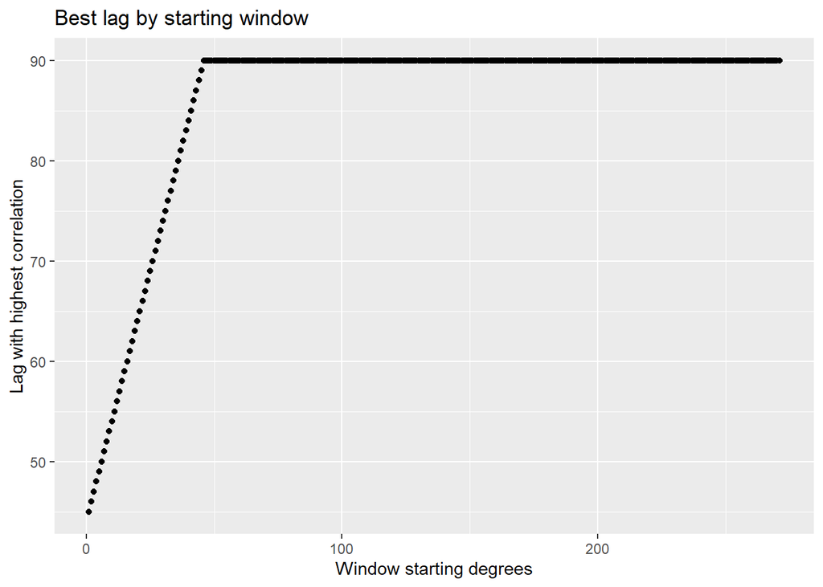

```r
tmpDB %>%
    filter(!is.na(p)) %>%
    group_by(startWindow) %>%
    filter(p==max(p)) %>%
    ungroup() %>%
    ggplot(aes(x=startWindow, y=lags)) +
    geom_point() +
    labs(x="Window starting degrees", y="Lag with highest correlation", title="Best lag by starting window")
```

As expected, a lag of 90 degrees always produces a high correlation. Since the curves are periodic, there is often a strong correlation at other values of lag also, though these are dependent on the starting point for the window and can also produce strong negative correlations.

The lag producing the highest correlation is consistently the closest allowable value to 90 degrees, which is known to be the answer for sin and cos.

This process can be leveraged to start looking at various coronavirus disease burden curves, to see what values of lag produce the best correlations given a specific window of time. Exploring this is the next step.

Suppose that the lag methods are run for the state of MI:

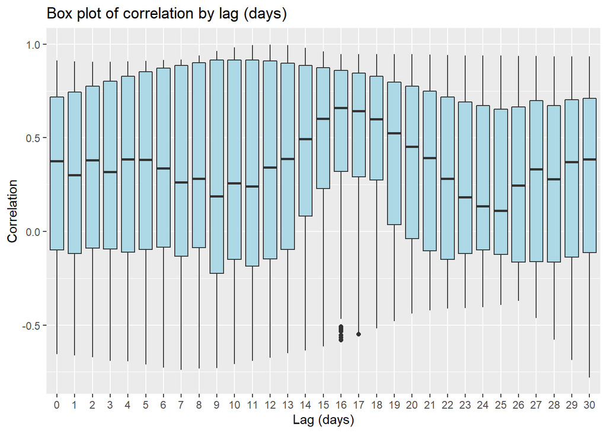

```r
# Extract the Michigan data
miData <- mwCurveList$dfList %>%
    filter(state=="MI", !is.na(vpm7), date>="2020-02-01", date<="2020-10-15") %>%
    arrange(date, name)

# Extract cases and deaths
miCases <- miData %>% filter(name=="CTP_cases") %>% pull(vpm7)
miDeaths <- miData %>% filter(name=="CTP_deaths") %>% pull(vpm7)

# Confirm that dates are the same for both vectors
miDates <- miData %>% filter(name=="CTP_cases") %>% pull(date)
if (!all.equal(miDates, miData %>% filter(name=="CTP_deaths") %>% pull(date))) stop("\nDate mismatch\n")

# Find the lags in the MI data
miLags <- lagVectorWindows(miDeaths, miCases, lagsTry=0:30, windowSize=56)

# Box plot for correlations by lag
miLags %>%
    filter(!is.na(p)) %>%
    ggplot(aes(x=factor(lags), y=p)) +
    geom_boxplot(fill="lightblue") +
    labs(x="Lag (days)", y="Correlation", title="Box plot of correlation by lag (days)")
```

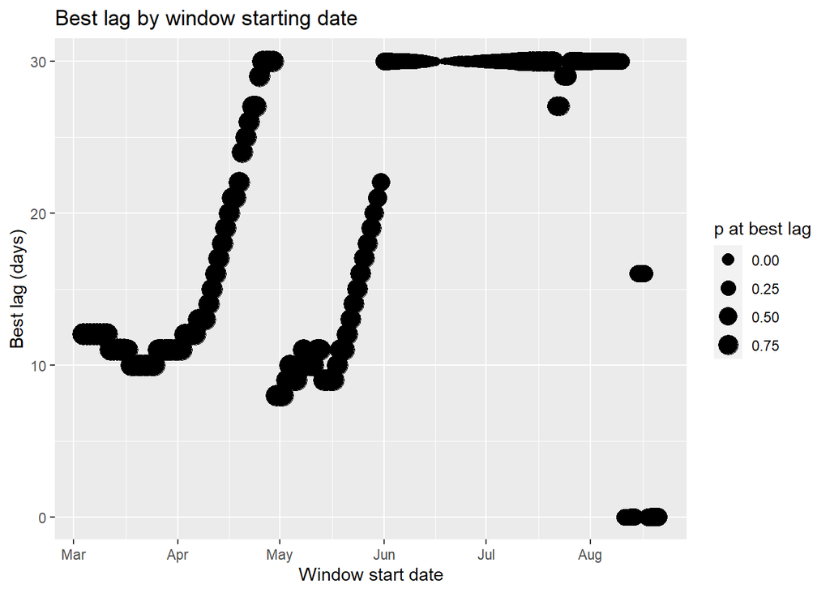

```r
miLags %>%
    filter(!is.na(p)) %>%
    group_by(startWindow) %>%
    filter(p==max(p)) %>%
    ggplot(aes(x=miDates[startWindow], y=lags)) +
    geom_point(aes(size=p)) +
    labs(x="Window start date", y="Best lag (days)", title="Best lag by window starting date") +
    scale_size_continuous("p at best lag") +
    scale_x_date(date_breaks="1 month", date_labels="%b")
```

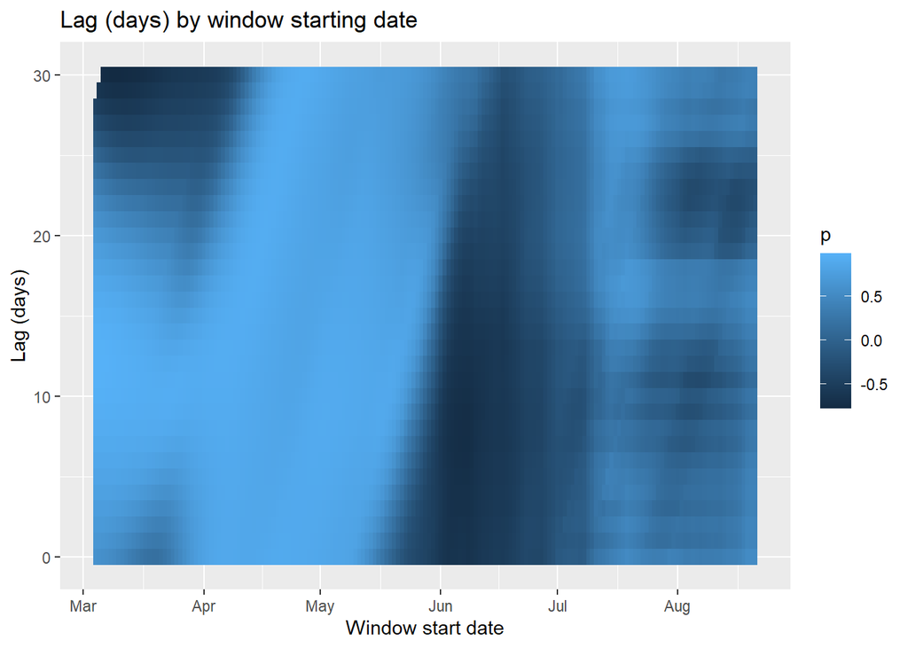

```r
miLags %>%
    filter(!is.na(p)) %>%
    ggplot(aes(x=miDates[startWindow], y=lags)) +
    geom_tile(aes(fill=p)) +
    labs(x="Window start date", y="Lag (days)", title="Lag (days) by window starting date") +
    scale_color_continuous("p at lag") +
    scale_x_date(date_breaks="1 month", date_labels="%b")
```

During the time when the spike in Michigan was growing, average “best lag” was in the 10-15 day range. A similar finding is observed in the area of the downslope of the spike in Michigan. The pattern that lag tends to climb linearly may be a feature of Michigan or of the methodology.

The process is converted to functional form:

```
##  Date[1:232], format: "2020-03-04" "2020-03-05" "2020-03-06" "2020-03-07" "2020-03-08" ...
## NULL
##  Date[1:232], format: "2020-03-04" "2020-03-05" "2020-03-06" "2020-03-07" "2020-03-08" ...
## NULL
```

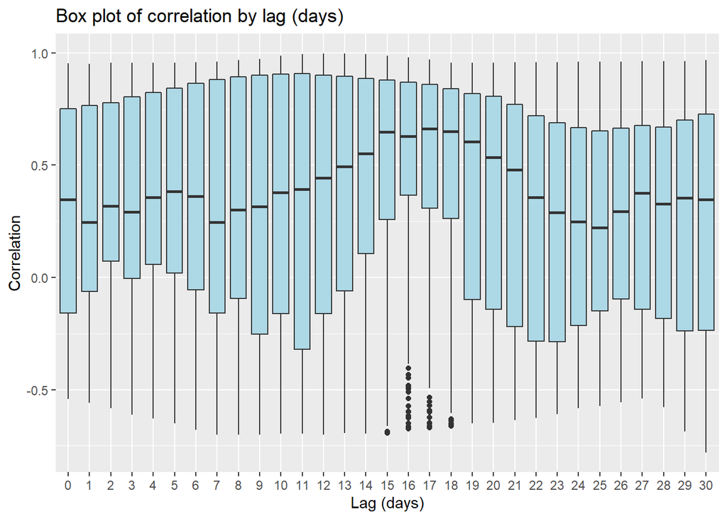

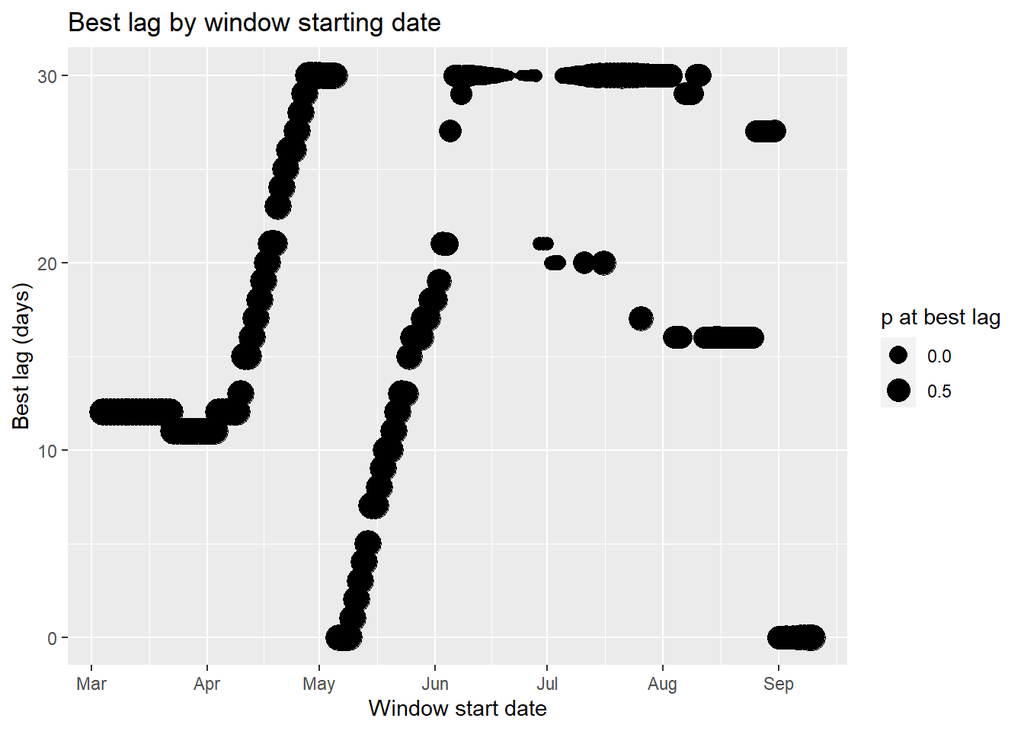

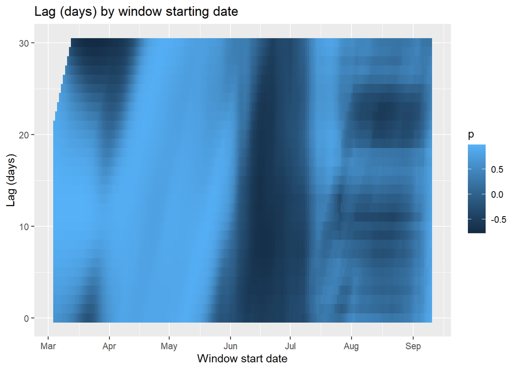

```r
# Function to assess correlations by lag and window by state
stateCorr <- function(lst,
                      keyState,
                      met="vpm7",
                      v1Name="CTP_deaths",
                      v2Name="CTP_cases",
                      windowSize=42
                      ) {

    # FUNCTION ARGUMENTS:
    # lst: the processed list
    # keyState: the state of interest
    # met: the metric of interest
    # v1Name: the name of the first vector
    # v2Name: the name of the second vector
    # windowSize: number of days in the window

    # Extract the data for the key State
    df <- lst[["dfList"]] %>%
        filter(state %in% keyState, !is.na(get(met))) %>%
        arrange(state, date, name)

    # Get the minimum date that is common to both
    minDate <- df %>%
        group_by(name) %>%
        summarize(date=min(date)) %>%
        pull(date) %>%
        max()

    # Extract v1 and v2
    v1 <- df %>%
        filter(name==v1Name, date>=minDate) %>%
        pull(met)
    v2 <- df %>%
        filter(name==v2Name, date>=minDate) %>%
        pull(met)

    # Confirm that dates are the same for both vectors
    dfDates1 <- df %>% filter(name==v1Name, date>=minDate) %>% pull(date)
    dfDates2 <- df %>% filter(name==v2Name, date>=minDate) %>% pull(date)
    str(dfDates1) %>% print()
    str(dfDates2) %>% print()
    if (!all.equal(dfDates1, dfDates2)) stop("\nDate mismatch\n")

    # Find the lags in the data
    dfLags <- lagVectorWindows(v1, v2, lagsTry=0:30, windowSize=windowSize) %>%
        mutate(windowStartDate=dfDates1[startWindow])

    # Boxplot of correlations by lag
    p1 <- dfLags %>%
        filter(!is.na(p)) %>%
        ggplot(aes(x=factor(lags), y=p)) +
        geom_boxplot(fill="lightblue") +
        labs(x="Lag (days)", y="Correlation", title="Box plot of correlation by lag (days)")
    print(p1)

    # Plot of best lags by starting date
    p2 <- dfLags %>%
        filter(!is.na(p)) %>%
        group_by(startWindow) %>%
        filter(p==max(p)) %>%
        ggplot(aes(x=windowStartDate, y=lags)) +
        geom_point(aes(size=p)) +
        labs(x="Window start date", y="Best lag (days)", title="Best lag by window starting date") +
        scale_size_continuous("p at best lag") +
        scale_x_date(date_breaks="1 month", date_labels="%b")
    print(p2)

    # Plot of correlations by lag
    p3 <- dfLags %>%
        filter(!is.na(p)) %>%
        ggplot(aes(x=windowStartDate, y=lags)) +
        geom_tile(aes(fill=p)) +
        labs(x="Window start date", y="Lag (days)", title="Lag (days) by window starting date") +
        scale_color_continuous("p at lag") +
        scale_x_date(date_breaks="1 month", date_labels="%b")
    print(p3)

    # Return dfLags
    dfLags

}


miLagData <- stateCorr(mwCurveList, keyState="MI")
```

```
##  Date[1:229], format: "2020-03-07" "2020-03-08" "2020-03-09" "2020-03-10" "2020-03-11" ...
## NULL
##  Date[1:229], format: "2020-03-07" "2020-03-08" "2020-03-09" "2020-03-10" "2020-03-11" ...
## NULL
```

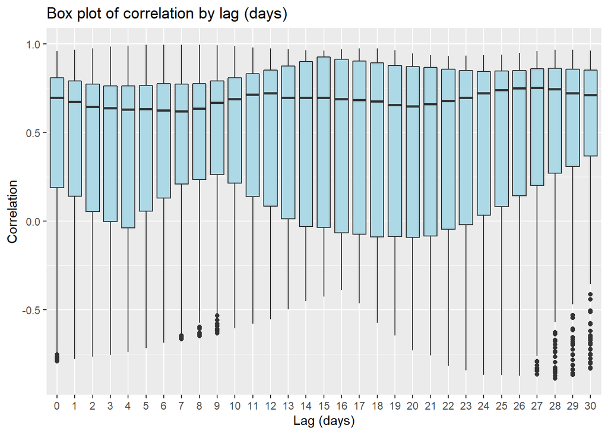

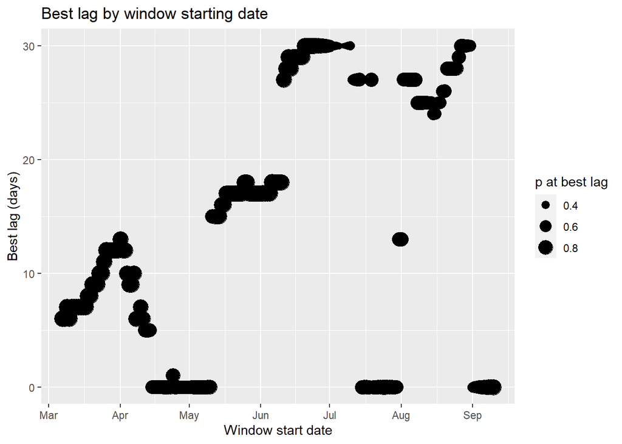

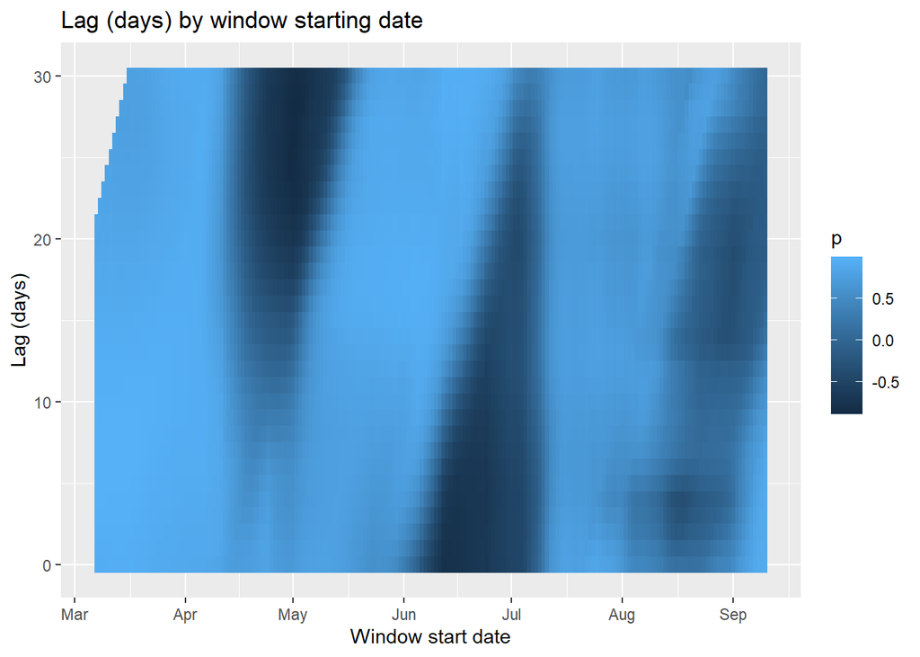

```r
ilLagData <- stateCorr(mwCurveList, keyState="IL")
```

```
##  Date[1:249], format: "2020-02-13" "2020-02-14" "2020-02-15" "2020-02-16" "2020-02-17" ...
## NULL
##  Date[1:249], format: "2020-02-13" "2020-02-14" "2020-02-15" "2020-02-16" "2020-02-17" ...
## NULL
```

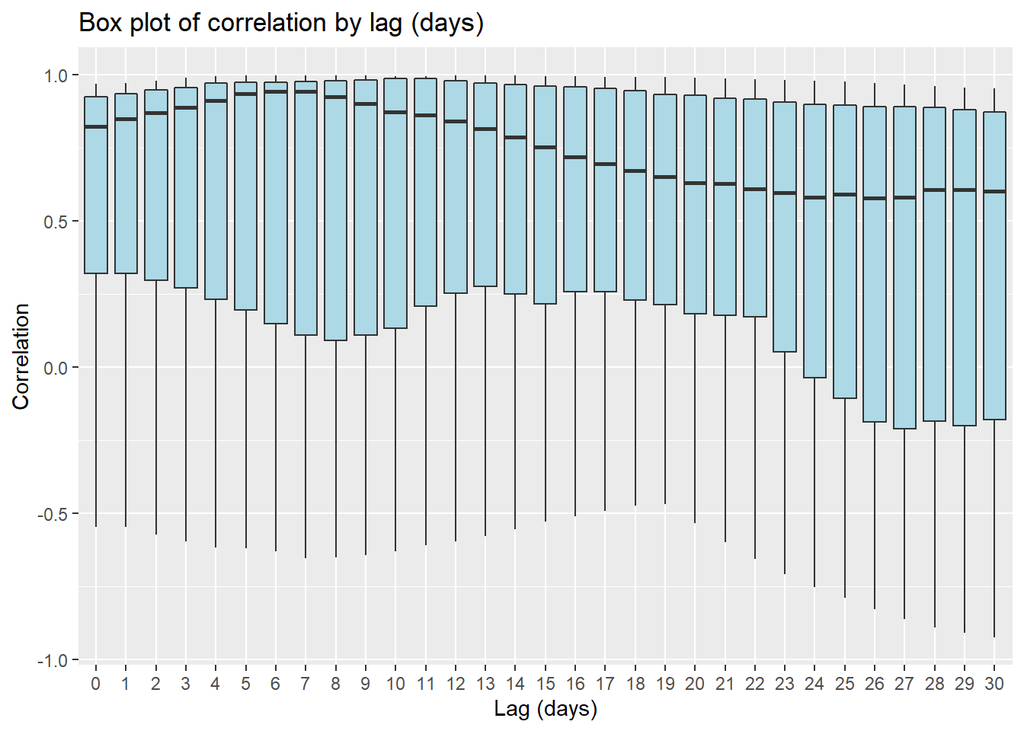

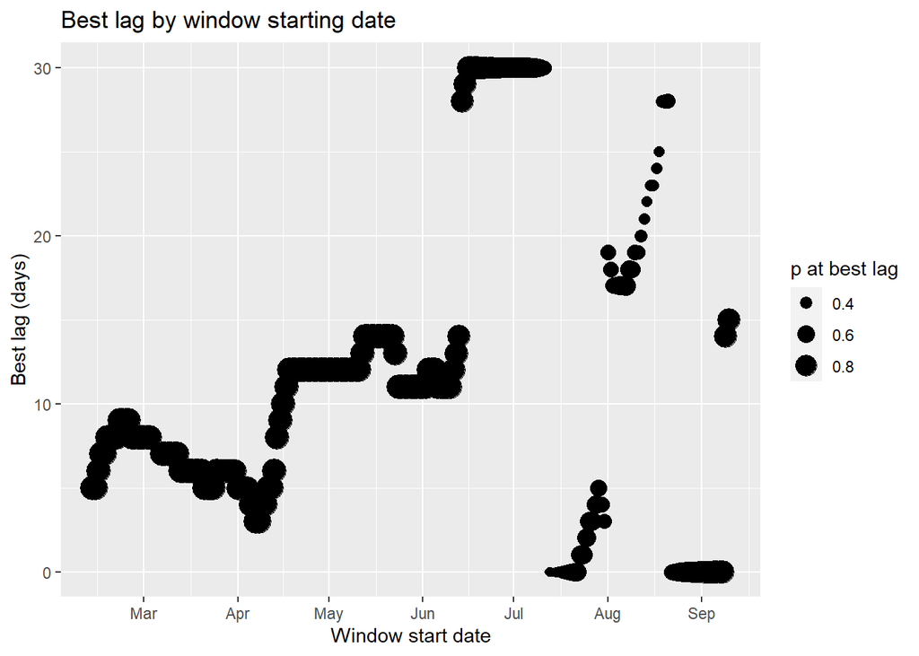

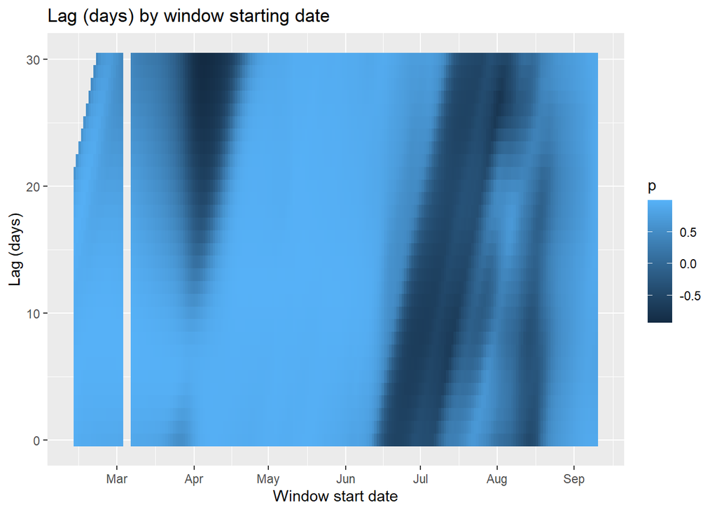

```r
nynjLagData <- stateCorr(neCurveList, keyState="NY/NJ")
```

The data suggest that there is a fairly discernible “best lag” around the time that there are bona fide spikes in both cases and deaths. A challenge is that there does not appear to be a discernible “best lag” at other times when spikes may be driven by factors like increased testing and/or there is more random noise in the data then clear patterns with a strong correlation.

A next step is to look at the reverse of this process and use lead(deaths) rather than lag(cases). This will allow for looking at time periods where cases begin to change rapidly and seeing whether these drive rapid changes in deaths at any particular lead time.

The function is updated to allow for either lags or leads:

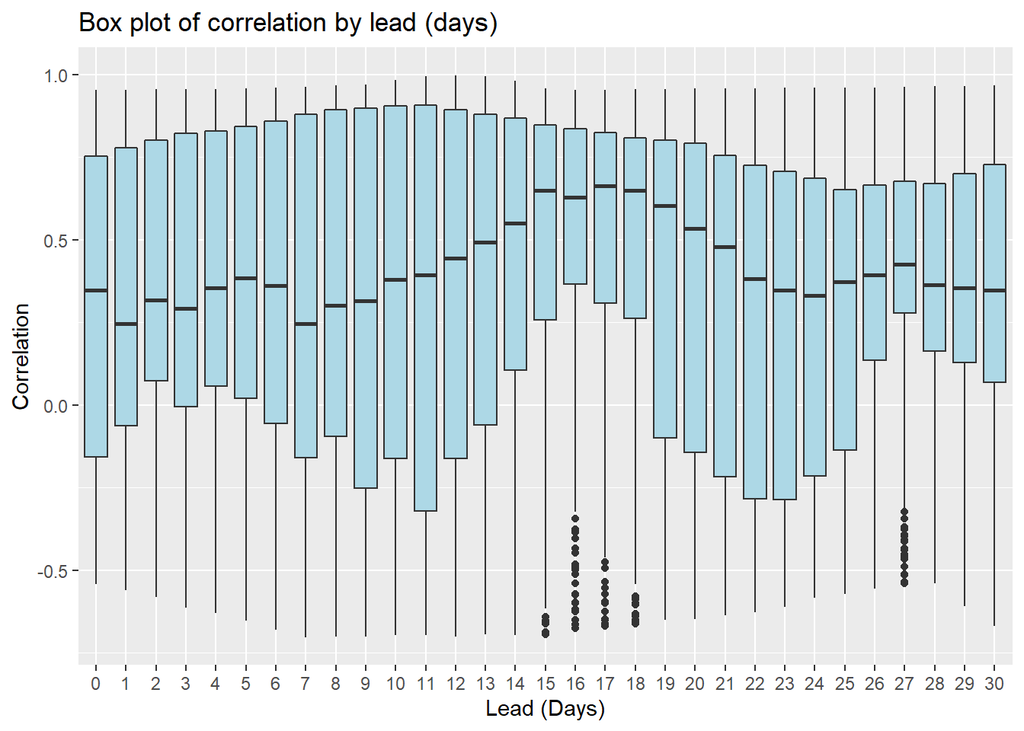

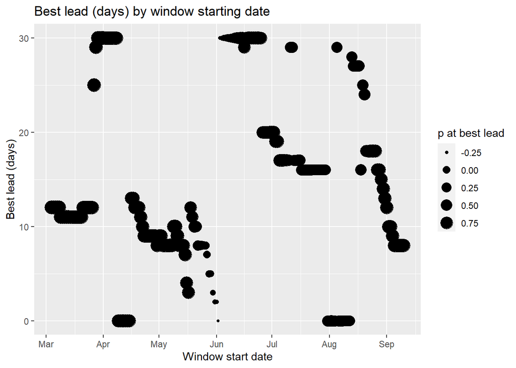

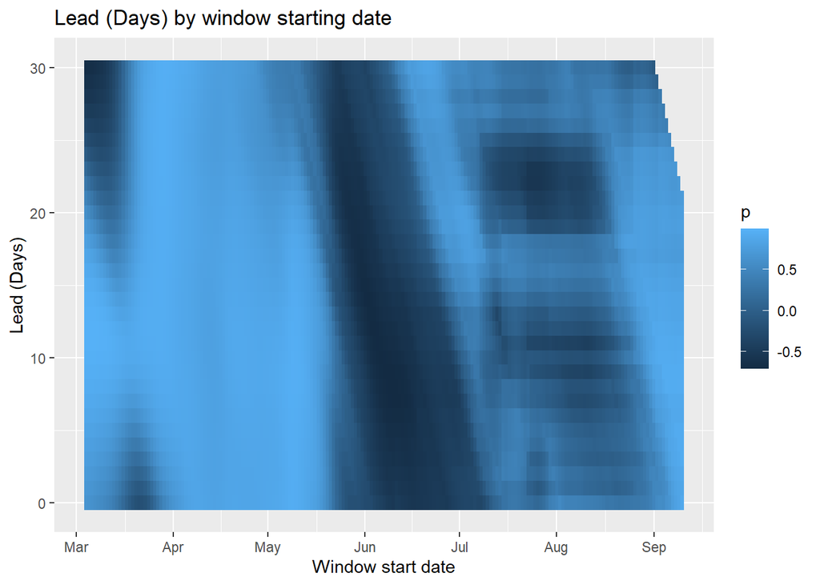

```r
lagVectorWindows <- function(v1,
                             v2,
                             lagsTry=0:30,
                             windowSize=30,
                             minNoNA=ceiling(windowSize/2),
                             updateStatus=FALSE,
                             isLag=TRUE
                             ) {

    # FUNCTION ARGUMENTS:
    # v1: the first vector, which will be used 'as is'
    # v2: the second vector, which will be lagged/led by various values for lagsTry
    # lagsTry: the values for x that will be used in cor(v1, lag/lead(v2, x))
    # windowSize: the size of the window to use in taking snippets of v1 and lagged/led v2
    # minNoNA: minimum number of non-NA lagged/led values needed to calculate a correlation
    # updateStates: whether to print which window is being worked on
    # isLag: boolean, should a lag or a lead be applied (TRUE is lag, FALSE is lead)

    # Find the function to be used
    func <- if (isLag) lag else lead

    # Find the list of all possible window start points
    windowStarts <- 1:(length(v1)-windowSize+1)

    # Helper function to create a frame of correlations
    helperCorr <- function(s) {

        # Create the end point for the vector
        e <- s + windowSize - 1

        # Announce the start
        if (updateStatus) cat("\nProcessing window starting at:", s)

        # Create the correlations tibble for all values of lag, and return
        tibble::tibble(startWindow=s, endWindow=e, lags=lagsTry) %>%
            mutate(na1=sum(is.na(v1[s:e])),
                   na2=sapply(lags, FUN=function(x) sum(is.na(func(v2, x)[s:e]))),
                   p=sapply(lags,
                            FUN=function(x) {
                                ifelse(sum(!is.na(func(v2, x)[s:e])) < minNoNA,
                                       NA,
                                       cor(v1[s:e], func(v2, x)[s:e], use="complete.obs")
                                       )
                                }
                            )
                   )
    }

    # Bind the correlations frames and return
    map_dfr(windowStarts, .f=helperCorr)

}



# Function to assess correlations by lag/lead and window by state
stateCorr <- function(lst,
                      keyState,
                      met="vpm7",
                      v1Name="CTP_deaths",
                      v2Name="CTP_cases",
                      windowSize=42,
                      isLag=TRUE
                      ) {

    # FUNCTION ARGUMENTS:
    # lst: the processed list
    # keyState: the state of interest
    # met: the metric of interest
    # v1Name: the name of the first vector (this is considered fixed)
    # v2Name: the name of the second vector (this will have the lead/lag applied to it)
    # windowSize: number of days in the window
    # isLag: boolean, whether to use lag (TRUE) or lead (FALSE) on v2Name

    # Extract the data for the key State
    df <- lst[["dfList"]] %>%
        filter(state %in% keyState, !is.na(get(met))) %>%
        arrange(state, date, name)

    # Get the minimum date that is common to both
    minDate <- df %>%
        group_by(name) %>%
        summarize(date=min(date)) %>%
        pull(date) %>%
        max()

    # Extract v1 and v2
    v1 <- df %>%
        filter(name==v1Name, date>=minDate) %>%
        pull(met)
    v2 <- df %>%
        filter(name==v2Name, date>=minDate) %>%
        pull(met)

    # Confirm that dates are the same for both vectors
    dfDates1 <- df %>% filter(name==v1Name, date>=minDate) %>% pull(date)
    dfDates2 <- df %>% filter(name==v2Name, date>=minDate) %>% pull(date)
    if (!all.equal(dfDates1, dfDates2)) stop("\nDate mismatch\n")

    # Find the lags in the data
    dfLags <- lagVectorWindows(v1, v2, lagsTry=0:30, windowSize=windowSize, isLag=isLag) %>%
        mutate(windowStartDate=dfDates1[startWindow])

    # Give the description of the lag or lead
    descr <- ifelse(isLag, "lag (days)", "lead (days)")

    # Boxplot of correlations by lag
    p1 <- dfLags %>%
        filter(!is.na(p)) %>%
        ggplot(aes(x=factor(lags), y=p)) +
        geom_boxplot(fill="lightblue") +
        labs(x=stringr::str_to_title(descr),
             y="Correlation",
             title=paste0("Box plot of correlation by ", descr)
             )
    print(p1)

    # Plot of best lags by starting date
    p2 <- dfLags %>%
        filter(!is.na(p)) %>%
        group_by(startWindow) %>%
        filter(p==max(p)) %>%
        ggplot(aes(x=windowStartDate, y=lags)) +
        geom_point(aes(size=p)) +
        labs(x="Window start date",
             y=paste0("Best ", descr),
             title=paste0("Best ", descr, " by window starting date")
             ) +
        scale_size_continuous(paste0("p at best ", stringr::str_replace(descr, " .*", ""))) +
        scale_x_date(date_breaks="1 month", date_labels="%b")
    print(p2)

    # Plot of correlations by lag
    p3 <- dfLags %>%
        filter(!is.na(p)) %>%
        ggplot(aes(x=windowStartDate, y=lags)) +
        geom_tile(aes(fill=p)) +
        labs(x="Window start date",
             y=stringr::str_to_title(descr),
             title=paste0(stringr::str_to_title(descr), " by window starting date")
             ) +
        scale_color_continuous(paste0("p at ", stringr::str_replace(descr, " .*", ""))) +
        scale_x_date(date_breaks="1 month", date_labels="%b")
    print(p3)

    # Rename variable lags to leads if isLag is FALSE
    if (isFALSE(isLag)) dfLags <- dfLags %>%
        rename(leads=lags)

    # Return dfLags
    dfLags

}


miLeadData <- stateCorr(mwCurveList, keyState="MI", v1Name="CTP_cases", v2Name="CTP_deaths", isLag=FALSE)
```

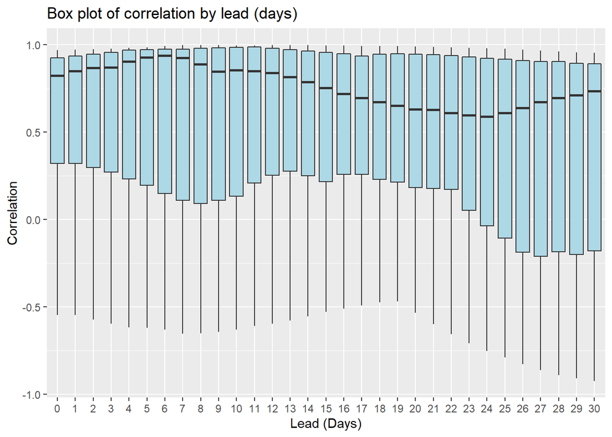

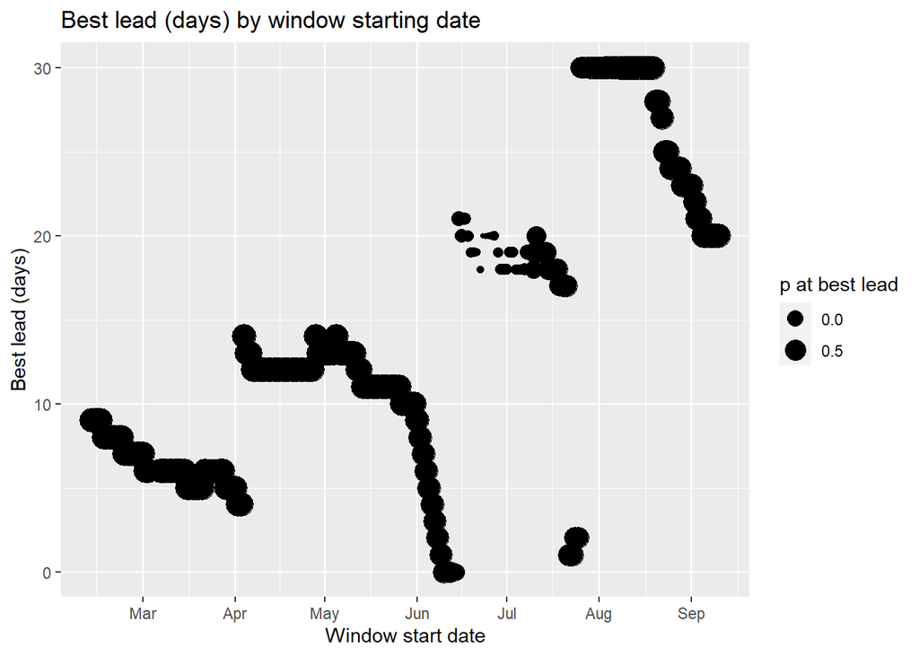

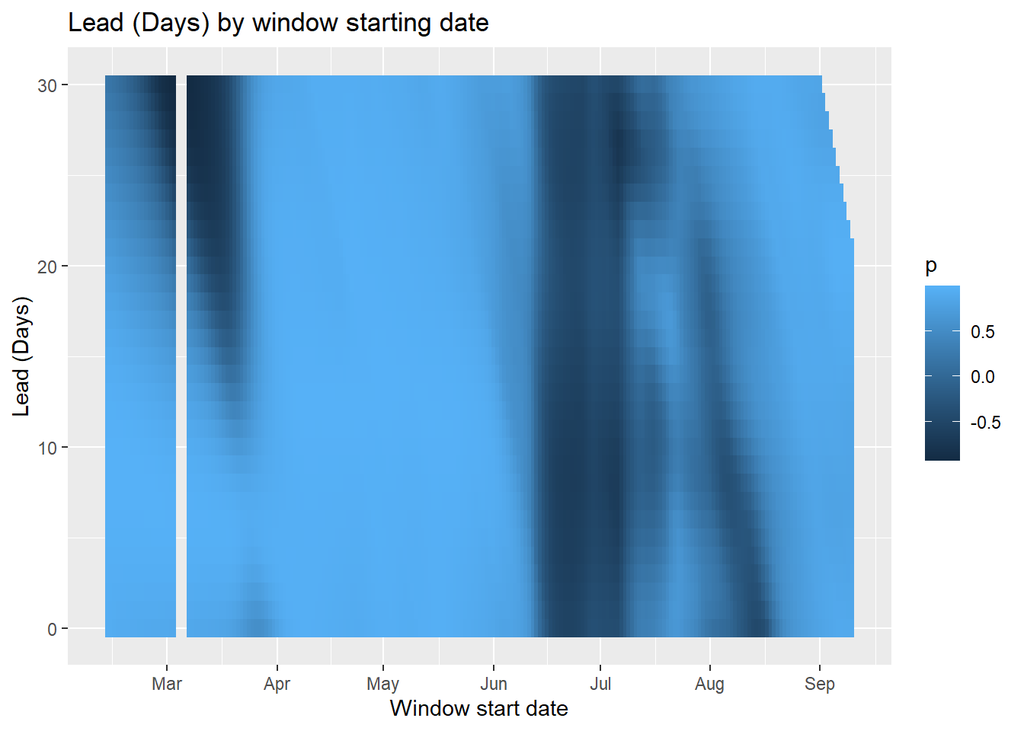

```r
nynjLeadData <- stateCorr(neCurveList, keyState="NY/NJ", v1Name="CTP_cases", v2Name="CTP_deaths", isLag=FALSE)
```

The leads continue to be more reliable in NY/NJ than in MI. The southern states with later disease outbreak can also be explored:

```
##
## Will scale by: 0.02075921
```

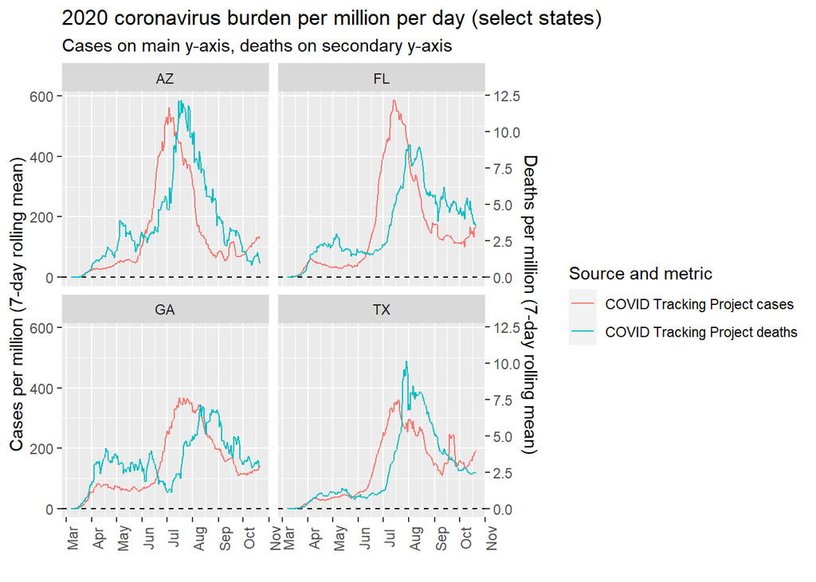

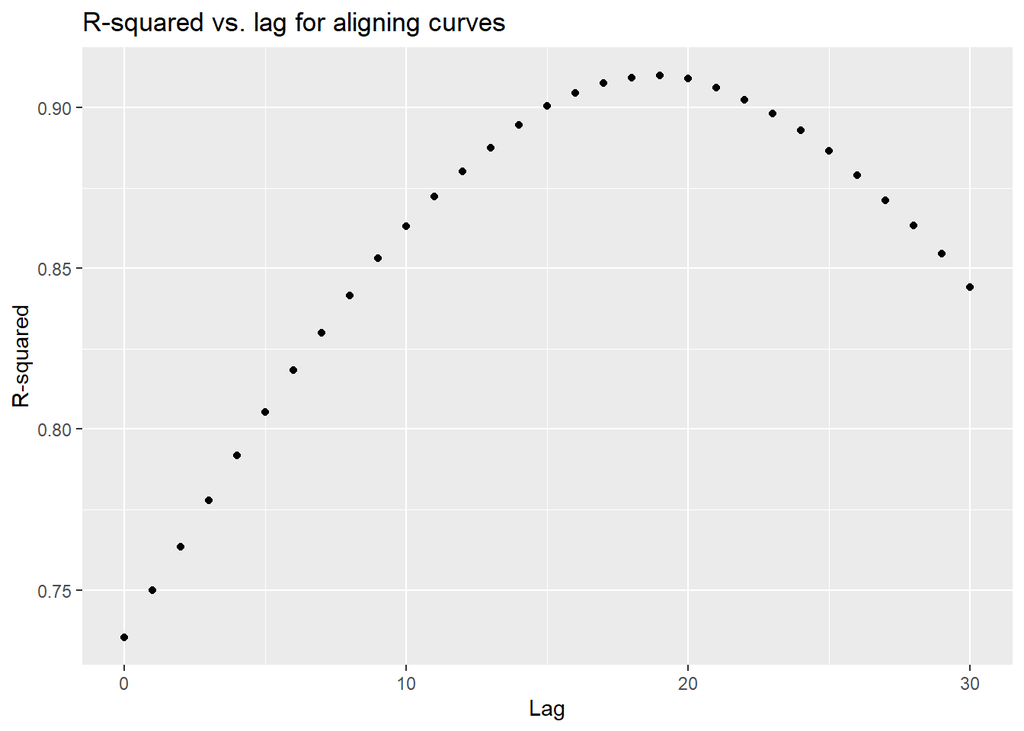

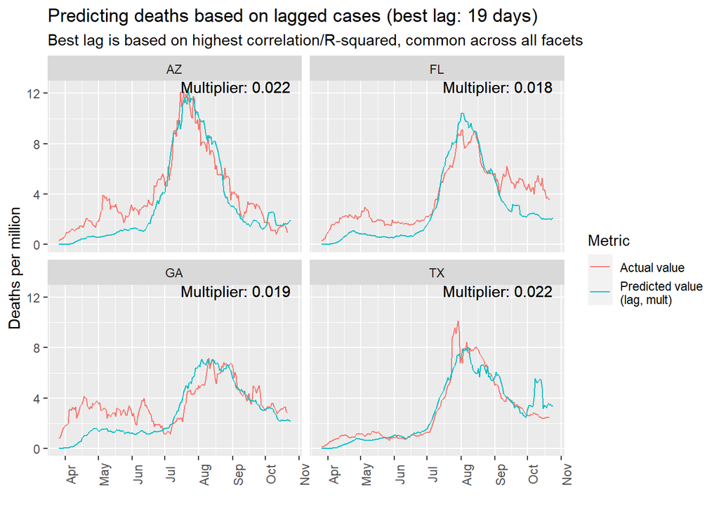

```r
# Example for southern states
soCurveList <- createAndAlignCurves(stateData,
                                    yVal="vpm7",
                                    namesPlot=c("CTP_cases"),
                                    namesSec=c("CTP_deaths"),
                                    keyStates=c("AZ", "FL", "GA", "TX"),
                                    plotTitle="2020 coronavirus burden per million per day (select states)",
                                    plotSub="Cases on main y-axis, deaths on secondary y-axis",
                                    primYLab="Cases per million (7-day rolling mean)",
                                    secYLab="Deaths per million (7-day rolling mean)",
                                    facetFixed=TRUE,
                                    popData=usafPrepped$usafDemo,
                                    printPlot=TRUE,
                                    lagValueMetric="vpm7",
                                    lagDepName="CTP_deaths",
                                    lagsTry=0:30
                                    )
```

```
## # A tibble: 4 x 3
##   state earlyLag lateLag
##   <chr>    <dbl>   <dbl>
## 1 GA          10      20
## 2 TX          10      20
## 3 FL          10      20
## 4 AZ          10      20
```

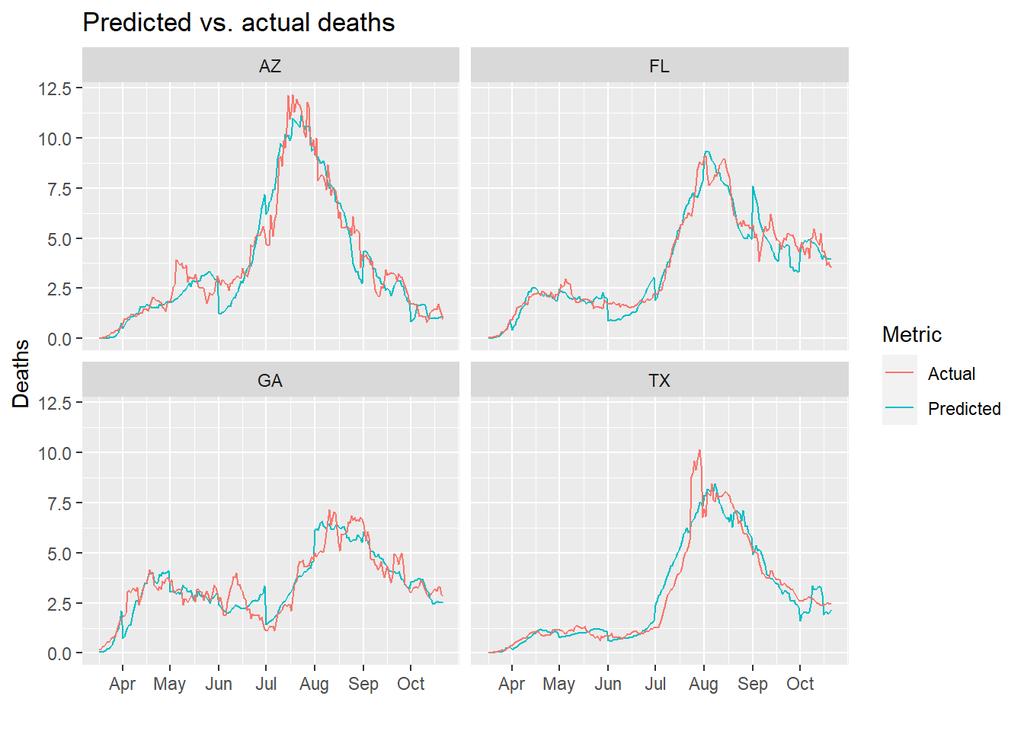

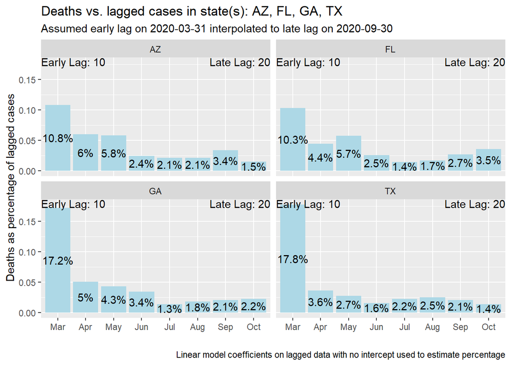

```
## # A tibble: 876 x 13
##    state date       CTP_cases CTP_deaths earlyLag lateLag   eLag  lLag pctEarly
##    <chr> <date>         <dbl>      <dbl>    <dbl>   <dbl>  <dbl> <dbl>    <dbl>
##  1 AZ    2020-03-17      1.17     0            10      20 0.0837    NA        1
##  2 AZ    2020-03-18      1.92     0.0209       10      20 0.146     NA        1
##  3 AZ    2020-03-19      2.93     0.0418       10      20 0.146     NA        1
##  4 AZ    2020-03-20      5.17     0.0418       10      20 0.126     NA        1
##  5 AZ    2020-03-21      7.05     0.105        10      20 0.146     NA        1
##  6 AZ    2020-03-22      8.83     0.126        10      20 0.146     NA        1
##  7 AZ    2020-03-23     11.2      0.167        10      20 0.272     NA        1
##  8 AZ    2020-03-24     14.0      0.272        10      20 0.293     NA        1
##  9 AZ    2020-03-25     16.1      0.293        10      20 0.398     NA        1
## 10 AZ    2020-03-26     16.0      0.314        10      20 0.732     NA        1
## # ... with 866 more rows, and 4 more variables: x <dbl>, y <dbl>, mon <fct>,
## #   pred <dbl>
```

```r
assessStateCFR(soCurveList,
               keyStates=c("AZ", "FL", "GA", "TX"),
               depVar="CTP_deaths",
               indepVar="CTP_cases",
               depTitleName="deaths",
               indepTitleName="cases"
               )
```

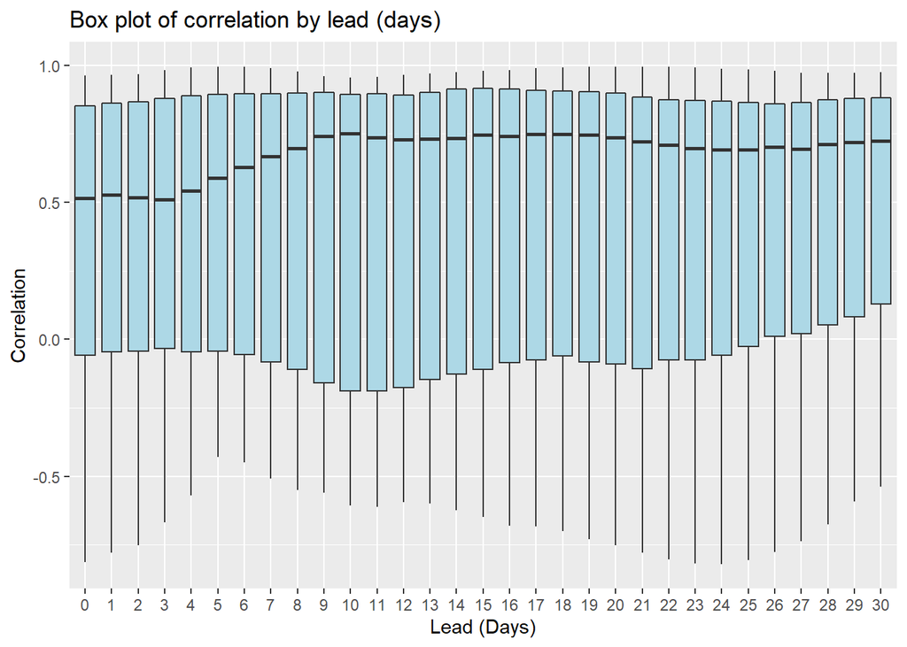

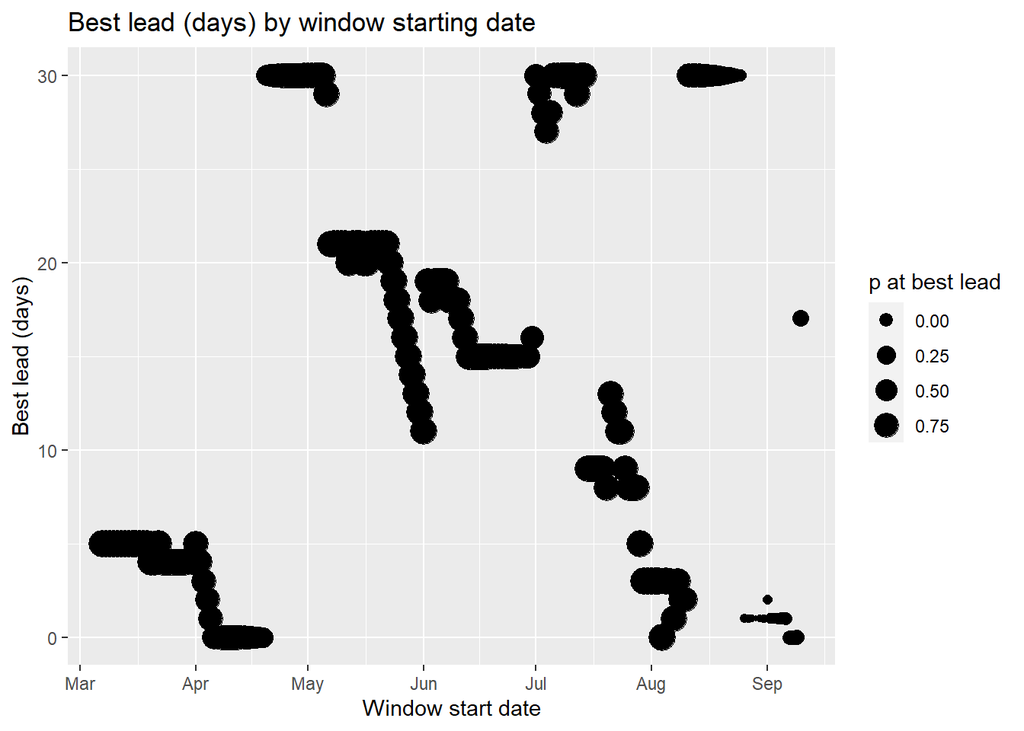

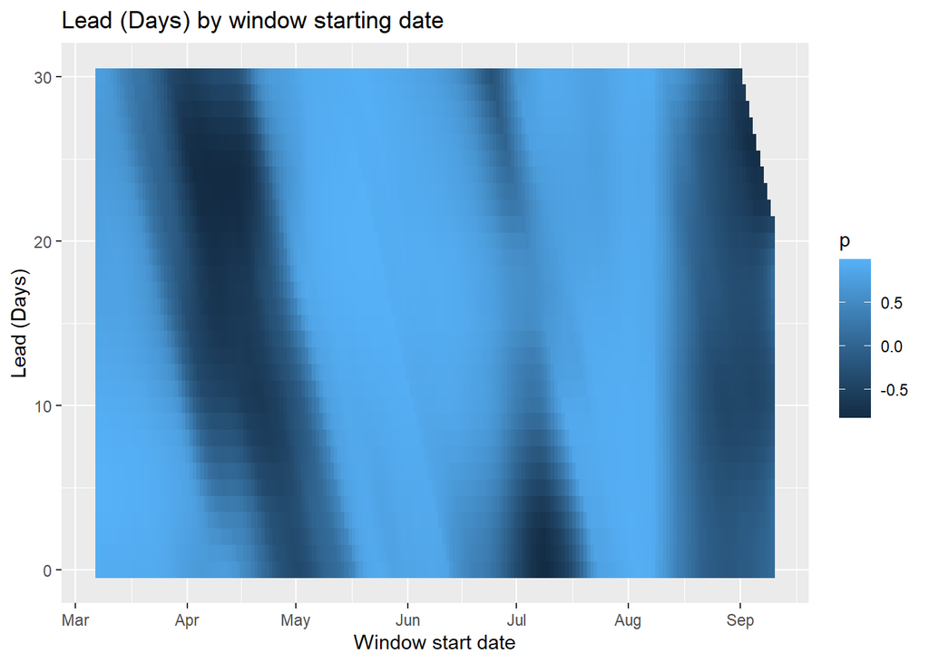

```r
txLeadData <- stateCorr(soCurveList, keyState="TX", v1Name="CTP_cases", v2Name="CTP_deaths", isLag=FALSE)
```

The lags and leads make the most sense around the areas where there is a significant spike in the data. The are fairly noisy otherwise. Does using a rolling average help with assessing leads?

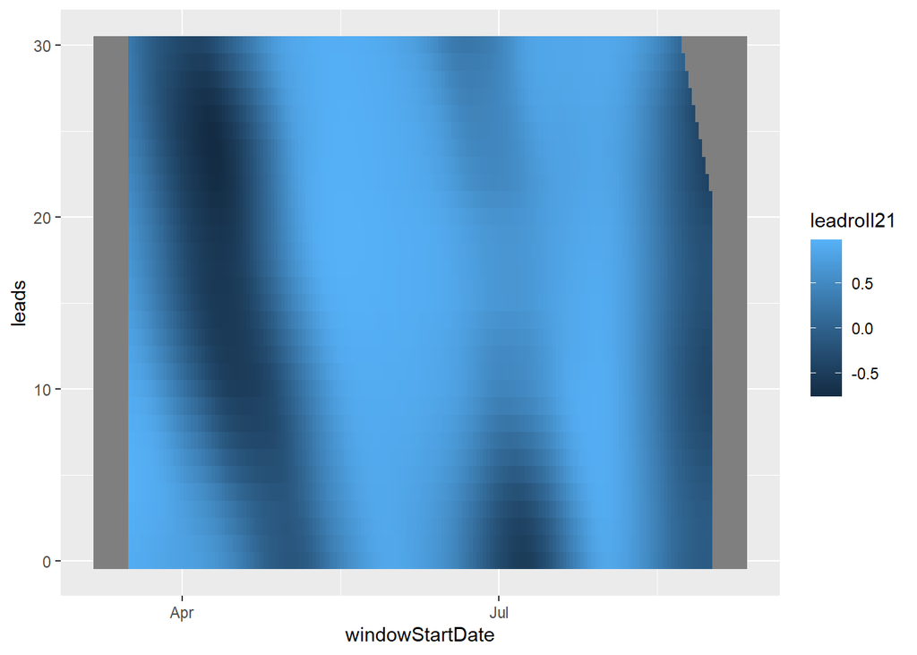

```r
txLeadRoll21 <- txLeadData %>%
    arrange(startWindow, leads) %>%
    group_by(leads) %>%
    mutate(leadroll7=zoo::rollmean(p, k=7, fill=NA), leadroll21=zoo::rollmean(p, k=21, fill=NA)) %>%
    ungroup()

txLeadRoll21 %>%
    ggplot(aes(x=windowStartDate, y=leads)) +
    geom_tile(aes(fill=leadroll21))
```

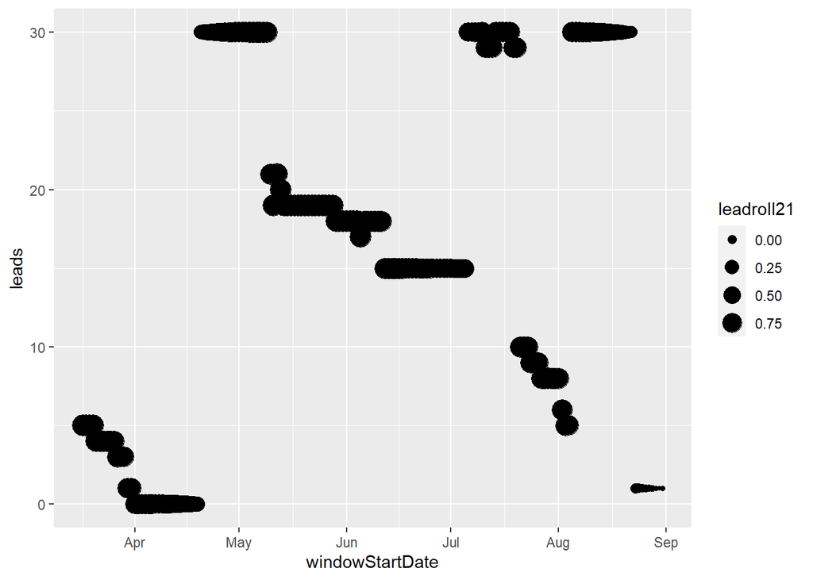

```r
txLeadRoll21 %>%
    filter(!is.na(leadroll21)) %>%
    group_by(windowStartDate) %>%
    filter(leadroll21==max(leadroll21)) %>%
    ggplot(aes(x=windowStartDate, y=leads)) +
    geom_point(aes(size=leadroll21))
```

In the main June-July time period when cases were climbing rapidly, the best lead appears to be in the 15-20 day range. The best lead at other times is not as clear, with noise in the data potentially drowning out the signal.

Data from late 2020 are integrated in to an overall state data file:

```r
# Create the CTP and USAF files
ctpPrepped_210106 <- prepCTPData(readFromRDS("old_hier5_210101"))
usafPrepped_210106 <- prepUSAFData(readFromRDS("cty_old_20210104")$clusterStateData)
```

```r
# Create an integrated state demographics file
demoData_210106 <- ctpPrepped_210106$ctpDemo %>%
    rename(popCTP=pop) %>%
    full_join(rename(usafPrepped_210106$usafDemo, popUSAF=pop), by="state") %>%
    mutate(pop=pmax(popCTP, popUSAF))

# Create the CDC file
cdcPrepped_210106 <- prepCDCData(readFromRDS("cdcList_20210105"), popData=demoData_210106)

# Create the integrated state data
stateData_210106 <- ctpPrepped_210106$ctpData %>%
    bind_rows(usafPrepped_210106$usafData) %>%
    bind_rows(cdcPrepped_210106$cdcData)
glimpse(stateData_210106)
```

```
## Rows: 126,003
## Columns: 9
## $ state  <chr> "AK", "AK", "AK", "AK", "AK", "AK", "AK", "AK", "AK", "AK", ...
## $ date   <date> 2020-03-06, 2020-03-07, 2020-03-08, 2020-03-09, 2020-03-10,...
## $ metric <chr> "cases", "cases", "cases", "cases", "cases", "cases", "cases...
## $ source <chr> "CTP", "CTP", "CTP", "CTP", "CTP", "CTP", "CTP", "CTP", "CTP...
## $ name   <chr> "CTP_cases", "CTP_cases", "CTP_cases", "CTP_cases", "CTP_cas...
## $ value  <dbl> 0, 0, 0, 0, 0, 0, 0, 0, 0, 0, 0, 3, 5, 3, 3, 1, 10, 13, 4, 7...
## $ value7 <dbl> NA, NA, NA, 0.0000000, 0.0000000, 0.0000000, 0.0000000, 0.00...
## $ vpm    <dbl> 0.000000, 0.000000, 0.000000, 0.000000, 0.000000, 0.000000, ...
## $ vpm7   <dbl> NA, NA, NA, 0.0000000, 0.0000000, 0.0000000, 0.0000000, 0.00...
```

```r
# Control totals
stateData_210106 %>%
    group_by(name) %>%
    summarize(value=sum(value, na.rm=TRUE), value7=sum(value7, na.rm=TRUE))
```

```
## # A tibble: 8 x 3
##   name             value     value7
##   <chr>            <dbl>      <dbl>
## 1 CDC_deaths    2626487.   2575402.
## 2 CDC_excess     291802.    289563.
## 3 CTP_cases    19629177   19028416.
## 4 CTP_deaths     335129     326469.
## 5 CTP_hosp     14567264   14092648.
## 6 CTP_tests   249943721  245268720.
## 7 USAF_cases   20000027   19318617.
## 8 USAF_deaths    341896     333434.
```

The process is run for the selected states in the northeast:

```
##
## Will scale by: 0.04857715
```

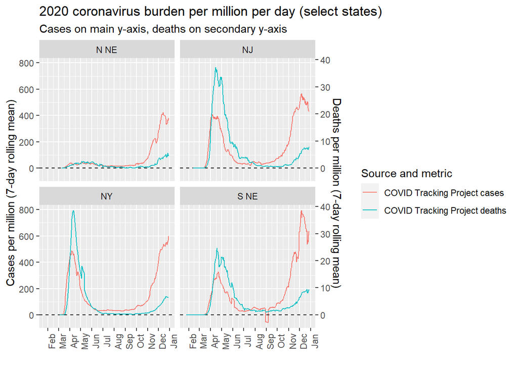

```r
# Example of combining states
ne_casedeath_210106 <- plotStateMetric(stateData_210106,
                                       yVal="vpm7",
                                       namesPlot=c("CTP_cases"),
                                       namesSec=c("CTP_deaths"),
                                       keyStates=c("NY", "NJ", "MA", "CT", "RI", "NH", "VT", "ME"),
                                       combStates=c("MA"="S NE", "CT"="S NE", "RI"="S NE",
                                                    "NH"="N NE", "VT"="N NE", "ME"="N NE"
                                                    ),
                                       plotTitle="2020 coronavirus burden per million per day (select states)",
                                       plotSub="Cases on main y-axis, deaths on secondary y-axis",
                                       primYLab="Cases per million (7-day rolling mean)",
                                       secYLab="Deaths per million (7-day rolling mean)",
                                       facetFixed=TRUE,
                                       popData=usafPrepped_210106$usafDemo,
                                       returnData=TRUE
                                       )
```

```r
ne_casedeath_210106
```

```
## # A tibble: 2,560 x 5
##    state date       name        vpm7     pop
##    <chr> <date>     <chr>      <dbl>   <dbl>
##  1 N NE  2020-03-03 CTP_cases     NA  626042
##  2 N NE  2020-03-03 CTP_deaths    NA  626042
##  3 N NE  2020-03-04 CTP_cases     NA 1956650
##  4 N NE  2020-03-04 CTP_deaths    NA 1956650
##  5 N NE  2020-03-05 CTP_cases     NA 1956650
##  6 N NE  2020-03-05 CTP_deaths    NA 1956650
##  7 N NE  2020-03-06 CTP_cases     NA 1956650
##  8 N NE  2020-03-06 CTP_deaths    NA 1956650
##  9 N NE  2020-03-07 CTP_cases     NA 3285978
## 10 N NE  2020-03-07 CTP_deaths    NA 3285978
## # ... with 2,550 more rows
```

The createAndAlignCurves() function is run for select northeast states:

```
##
## Will scale by: 0.04640771
```

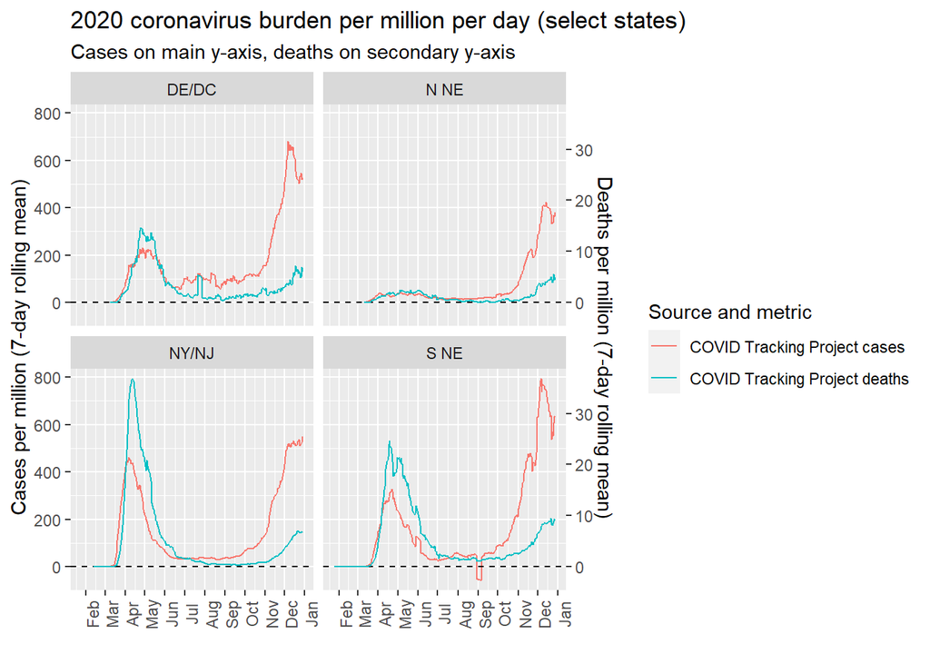

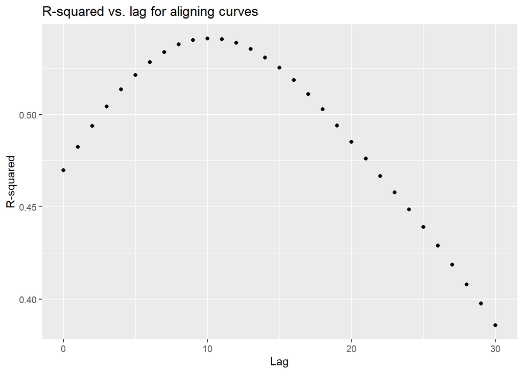

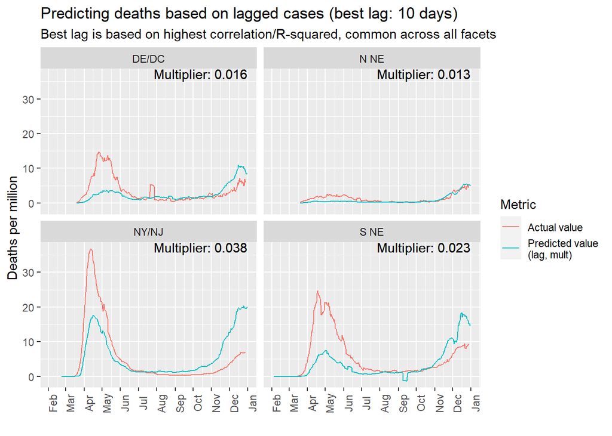

```r
# Example for northeastern states
neCurveList_210106 <- createAndAlignCurves(stateData_210106,
                                           yVal="vpm7",
                                           namesPlot=c("CTP_cases"),
                                           namesSec=c("CTP_deaths"),
                                           keyStates=c("NY", "NJ", "MA", "CT", "RI",
                                                       "NH", "VT", "ME", "DE", "DC"
                                                       ),
                                           combStates=c("MA"="S NE", "CT"="S NE", "RI"="S NE",
                                                        "NH"="N NE", "VT"="N NE", "ME"="N NE",
                                                        "NY"="NY/NJ", "NJ"="NY/NJ",
                                                        "DE"="DE/DC", "DC"="DE/DC"
                                                        ),
                                           plotTitle="2020 coronavirus burden per million per day (select states)",
                                           plotSub="Cases on main y-axis, deaths on secondary y-axis",
                                           primYLab="Cases per million (7-day rolling mean)",
                                           secYLab="Deaths per million (7-day rolling mean)",
                                           facetFixed=TRUE,
                                           popData=usafPrepped_210106$usafDemo,
                                           printPlot=TRUE,
                                           lagValueMetric="vpm7",
                                           lagDepName="CTP_deaths",
                                           lagsTry=0:30
                                           )
```

There is a clear difference in deaths per case that prevents full alignment of the curves using a single ratio and lag. The death rate as a function of confirmed cases is significantly higher in April and May than in late 2020.